# CM20261020_Hopping_eff_based_on_single_LPs

Christine

2026-10-20

#Aim The aim is to look for differences in hopping efficiency based on different genomic locations of the launch pad’s (LPs). We have multiple options to tackle this. In this analysis I am focusing on the single integration launch pads. The prerequisite is that the comparisons are between LPs with the same insert. Hopping efficiency has been determined by the number of parsed reads that map to the home location or not, resulting in fractions of home or hopped.

We ran Christines pipeline to estimate the hopped fraction, the final output tsv files can be found here: /home/c.moene/projects/hopping_technology/SB_transposition_manuscript/Transposed_fraction/output_ME20260326

Here we only process the files with a neutral insert (for figure 1). The other inserts are processed in figure 3.

#workfow - load the tsv files into R - plot LP versus hopping efficiency

#Setup

```r
library(stringr)
library(dplyr)
```

```r
library(readr)
library(tidyr)
library(ggplot2)
library(Biostrings)
library(GenomicRanges)
library(tibble)
library(RColorBrewer)
library(ggpubr)

split_string <- function(vect,sep,N1,N2=N1){
  library(stringr)
  sapply(vect, function(X){
    paste(str_split(X,sep)[[1]][N1:N2],collapse = sep)
  },USE.NAMES = F)
}
source('/home/c.moene/projects/hopping_technology/01_genomewide_chromatin_background/CM20260330_compute_chromatin_background.R')
```

#Paths and parameters

```r
#datatag
datetag = paste0("CM",format(Sys.time(), '%Y%m%d'))

# Prepare output
output_dir <- paste0("/home/c.moene/projects/hopping_technology/03_hopping_eff_single_LPs/figures/",datetag)
dir.create(output_dir, showWarnings = FALSE)
```

```r
library(knitr)
opts_chunk$set(cache = T,
               message = F, warning = F,
               dev=c('png', 'pdf'),
               dpi = 300,
               fig.path = paste0(file.path(output_dir), "/"))
pdf.options(useDingbats = FALSE)
```

# Combine all output files

```r
# List all files
metadata <- tibble(file = dir('/home/c.moene/projects/hopping_technology/SB_transposition_manuscript/Transposed_fraction/output_ME20260326',
                   recursive = T, full.names = T)) %>%
  mutate(sample = str_remove(basename(file), "\\..*"))


# Load all files
hopping_eff_tib <- bind_rows(lapply(1:nrow(metadata),
                        function(i) {
                          tmp <- read_tsv(metadata$file[i],
                                          col_types = cols(
                                            .default = col_character(),
                                            total_reads  = col_double(),
                                            home_reads  = col_double(),
                                            fract_home_reads = col_double())) %>%
                            mutate(sample = metadata$sample[i])
                        }))

hopping_eff_tib = hopping_eff_tib %>%
  mutate(orientation = case_when(grepl("Fw|fw", sample_name) ~ "fw",
                                 grepl("Rv|rv", sample_name) ~ "rv",
                                 .default = 'unknown'))
```

# Curate dataset - remove bad samples

Notes: there seems to be something wrong with the fw mapping of E1792_N31_D11_fw, E1792_N37_D4_fw, E1792_N37_D11_fw (very few reads and basically no home reads). I filter for samples that have sufficient reads:

```r
#check how many samples have low total reads
hopping_eff_tib %>% filter(total_reads < 500) %>% pull(sample_name)
```

```
## [1] "E1682_Tdgf1_D10_fw"           "E1682_Tdgf1_D4_fw"
## [3] "E1682_Tdgf1_D6_fw"            "E1682_Tdgf1_D8_fw"
## [5] "E2226_3xCTCF_non_sorted_4_fw"
```

```r
hopping_eff_tib %>% filter(home_reads < 100) %>% pull(sample_name)
```

```
## [1] "E1682_Tdgf1_D10_fw"           "E1682_Tdgf1_D4_fw"
## [3] "E1682_Tdgf1_D6_fw"            "E1682_Tdgf1_D8_fw"
## [5] "E1792_N31_D11_fw"             "E1792_N37_D11_fw"
## [7] "E1792_N37_D4_fw"              "E2226_3xCTCF_non_sorted_4_fw"
```

```r
#How different are the Tdgf1 samples
hopping_eff_tib %>% filter(grepl("Tdgf1", sample_name))
```

```
## # A tibble: 5 × 7
##   sample_name        launch_pad total_reads home_reads fract_home_reads sample
##   <chr>              <chr>            <dbl>      <dbl>            <dbl> <chr>
## 1 E1682_Tdgf1_D10_fw N1                 110         40            0.364 E1682_T…
## 2 E1682_Tdgf1_D4_fw  N1                 138         31            0.225 E1682_T…
## 3 E1682_Tdgf1_D6_fw  N1                 134         31            0.231 E1682_T…
## 4 E1682_Tdgf1_D8_fw  N1                  46         16            0.348 E1682_T…
## 5 E1792_Tdgf1_D10_fw N1               28413       9793            0.345 E1792_T…
## # ℹ 1 more variable: orientation <chr>
```

Filtering this way removes most of the Tdgf1 samples, apparently they are sequenced very shallow. The fract_home reads of the samples is between 22-36% and it looks like the fraction is increasing with later timepoints of harvested gDNA. This could indicate that there is still hopping going on, specially between D4 and D8.

```r
hopping_eff_tib_filt = hopping_eff_tib %>%
  dplyr::filter(total_reads >= 500 & home_reads >= 100)

#Set filter so that Tdgf1 is included but the bad home location samples are not
hopping_eff_tib_filt_2 = hopping_eff_tib %>%
  dplyr::filter(home_reads >= 15)
```

## Remove samples that are not usable

E2143 - Remove E2143 from tibble, those are a mix of pCM008 and pCM010, as it is a mix of 6 pools generated in E2016 and already tagmented in E2048. Therefore, no reason to use E2143 for the technology paper

E2866 - Remove E2866 from tibble, Laurens hopped the Nanog construct but didnt take gDNA before sorting for GFP loss, therefore it is not usable for this analysis.

```r
hopping_eff_tib_wide = hopping_eff_tib_filt_2 %>%
  mutate(sample_base = str_remove(sample_name, "_(Fw|Rv|fw|rv)$")) %>%
  select(-sample, -sample_name, -total_reads, -home_reads) %>%
  pivot_wider(id_cols = c(sample_base, launch_pad), names_from = orientation, values_from = fract_home_reads) %>%
   rowwise() %>%
  mutate(
         fw_over_rv = fw/rv, #to detect problematic samples
         mean_fract_home = mean(c_across(cols = c(fw,rv)), na.rm = T), #(fw+rv)/2,
         mean_fract_hopped = 1-mean_fract_home,) %>%
  filter(!grepl("E2143", sample_base)) %>%
  filter(!grepl("E2866", sample_base)) %>% #filter out E2143 & E2866
  ungroup()


hopping_eff_tib_wide_grouped = hopping_eff_tib_wide %>%
  mutate(sample_group = case_when(sample_base %in% paste0("E2288_MVP", 1:5) ~ "E2288_MVP_C1",
                                  sample_base %in% paste0("E2288_MVP", 6:10) ~ "E2288_MVP_C6",
                                  sample_base %in% paste0("E2048_NanogS08_P", 31:39) ~ "E2048_NanogS08",
                                  sample_base %in% paste0("E2048_NanogS10_P", 1:51) ~ "E2048_NanogS10",
                                  grepl("E2226|E2285|E2292", sample_base) ~ str_remove(sample_base, "_[0-9]*$"),
                                  .default = sample_base)) %>%
  group_by(launch_pad, sample_group) %>%
  mutate(launch_pad = case_when(grepl("Fzd5", sample_base) ~ "Fzd5",
                                grepl("Tdgf1", sample_base) ~ "Tdgf1",
                                .default = launch_pad)) %>%
  summarize(mean_fw = mean(fw),
            mean_rv = mean(rv),
            mean_fract_home  = mean(mean_fract_home),
            mean_fract_hopped  = mean(mean_fract_hopped ))
```

## annotate dataframe

Infos to constructs: CM002 and CM003 have a short PA signal (snRP1) CM008 has SV40 polyA signal, wrong orientation (same as Sox2 constructs) CM010 has short polyA signal (snRP1)

```r
# In the pipeline, the nested PB-SB pLD037 inserts from Lise are given the same launch pad position, called N1 in this case. This is because they all have the same sequence because they are not reaching the genome, therefore we have to assign the right LP here.


samples_annotated = hopping_eff_tib_wide %>%
  mutate(sample_group = case_when(sample_base %in% paste0("E2288_MVP", 1:5) ~ "E2288_MVP_C1",
                                  sample_base %in% paste0("E2288_MVP", 6:10) ~ "E2288_MVP_C6",
                                  sample_base %in% paste0("E2048_NanogS08_P", 31:39) ~ "E2048_NanogS08",
                                  sample_base %in% paste0("E2048_NanogS10_P", 1:51) ~ "E2048_NanogS10",
                                  grepl("E2226|E2285|E2292|E2143", sample_base) ~ str_remove(sample_base, "_[0-9]*$"),
                                  .default = sample_base)) %>%
  select(sample_base, sample_group, launch_pad) %>%
  mutate(experiment = str_remove(sample_base, "_.*$"),
         insert = case_when(experiment == "E1177" ~ "pJOYC037",
                            experiment %in% c('E1682', 'E1792') ~ 'pLD037',
                            experiment == "E1665" ~  "pME013", #cell line CBS16 = pME013
                            grepl("NanogS08", sample_base) ~ "pCM008",
                            grepl("NanogS10", sample_base) ~ "pCM010",
                            experiment == "E2288" ~ "pMV001",
                            experiment == "E2143" ~ NA, #check, I think this is actually a mix of pCM008 and pCM010, so cannot really analyse
                            grepl("16A", sample_base) ~ "pME016",
                            grepl("CBS16", sample_base) ~ "pME013",
                            grepl("_34", sample_base) ~ "pME034",
                            grepl("_41", sample_base) ~ "pME041",
                            grepl("3xCTCF", sample_base) ~  "pME038",
                            grepl("CRE6", sample_base) ~ "CRE6",
                            grepl("MK[0]?1", sample_base) ~ "pMK01", #matches MK01 and MK1
                            grepl("MK[0]?2", sample_base) ~ "pMK02",
                            grepl("MK[0]?3", sample_base) ~ "pMK03",
                            grepl("MK[0]?3", sample_base) ~ "pMK03",
                            experiment == "E2902" ~ "pJOYC037",
                            grepl("_LoxP", sample_base) ~ "pLD037",
                            sample_base == "E1845_NanogS" ~ "pCM002",
                            sample_base == "E1845_NanogS_techrep1" ~ "pCM002",
                            sample_base == "E1845_NanogL" ~ "pCM003",
                            sample_base == "E1845_NanogL_techrep1" ~ "pCM003",
                            grepl("NRF1", sample_base) ~ "TFR_NRF1",
                            grepl("OCT4SOX2", sample_base) ~ "TFR_Oct4_Sox2",
                            grepl("P53", sample_base) ~ "TFR_P53",
                            grepl("Random2", sample_base) ~ "TFR_Random2",
                            grepl("STAT3", sample_base) ~ "TFR_STAT3"),
         launch_pad = case_when(grepl("Fzd5", sample_base) ~ "Fzd5",
                                grepl("Tdgf1", sample_base) ~ "Tdgf1",
                                .default = launch_pad)
  )

sample_group_annotated = samples_annotated %>%
  dplyr::select(-sample_base) %>%
  distinct()
```

# Combine data

```r
hopping_eff_tib_wide_annot =
  hopping_eff_tib_wide_grouped %>%
  left_join(sample_group_annotated)

# Annotate biological or technical replicates (we count the different measurement days from Lise as technical replicates since they come from the same transfections)
hopping_eff_tib_wide_annot2 =
  hopping_eff_tib_wide_annot %>%
  mutate(bio_rep = case_when(launch_pad == "A1" ~ "rep1",
                             launch_pad == "C10" ~ "rep1",
                             sample_group == "E2716_23_34A" ~ "rep4",
                             grepl("E2555_", sample_group) ~ split_string(sample_group, "_", 2),
                             grepl("E2716_", sample_group) ~ split_string(sample_group, "_", 2),
                             grepl("E1845_LoxP", sample_group) ~ "rep2",
                             insert == "pLD037" ~ "rep1",
                             sample_group == "E2226_CRE6_non_sorted" ~ "rep1",
                             sample_group == "E2347_CRE6" ~ "rep2",
                             grepl("E1665_", sample_group) ~ "rep1",
                             sample_group == "E2226_CBS16_non_sorted" ~ "rep2",
                             sample_group == "E2226_16A_non_sorted" ~ "rep1",
                             sample_group == "E2138_23_34A" ~ "rep1",
                             sample_group == "E2282_23_34A_WT_ctrl" ~ "rep2",
                             sample_group == "E2285_34A_ctrl" ~ "rep3",
                             sample_group == "E2282_23_34A_DelD2_ctrl" ~ "rep1",
                             sample_group == "E2282_23_34A_DelE12_ctrl" ~ "rep1",
                             sample_group == "E2347_23_34A_delD2" ~ "rep2",
                             sample_group == "E2347_23_34A_delE12" ~ "rep2",
                             sample_group == "E2226_3xCTCF_non_sorted" ~ "rep1",
                             sample_group == "E2347_3xCTCF" ~ "rep2",
                             sample_group == "E2285_MK01_ctrl" ~ "rep1",
                             sample_group == "E2401_23_MK01_ctrl" ~ "rep2",
                             sample_group == "E2285_MK02_ctrl" ~ "rep1",
                             sample_group == "E2401_23_MK02_ctrl" ~ "rep2",
                             sample_group == "E2285_MK03_ctrl" ~ "rep1",
                             sample_group == "E2401_23_MK03_ctrl" ~ "rep2",
                             launch_pad == "LP8" ~ "rep1",
                             experiment == "E2048" ~ "rep1",
                             experiment == "E2288" ~ "rep1",
                             experiment == "E1177" ~ "rep1",
                             sample_group == "E2902_WT78_1_SB" ~ "rep2",
                             sample_group == "E2902_WT79_1_SB" ~ "rep2",
                             sample_group == "E2902_WT83_1_SB" ~ "rep2",
                             sample_group == "E2902_WT78_2_SB" ~ "rep3",
                             sample_group == "E2902_WT79_2_SB" ~ "rep3",
                             sample_group == "E2902_WT83_2_SB" ~ "rep3",
                             .default = "rep1")) %>%
  mutate(launch_pad = factor(launch_pad, levels = c("C9", "LP23", "LP8", "A1", "C10", "Fzd5", "Lise_F108", "N1", "Lise_N31", "Lise_N37", "Tdgf1", "Lise_T3", "Lise_T48", "Lise_T137", "pJOYC037")),
         genotype = case_when(grepl("elD2", sample_group) ~ "delD2",
                              grepl("elE12", sample_group) ~ "delE12",
                              grepl("_mCh-_", sample_group) ~ "mCh_del",
                              .default = "WT"))
```

# Plot hopping efficiency based on launch pad position

## Plot neutral insert

Combine CRE6 and pLE037 as neutral inserts here

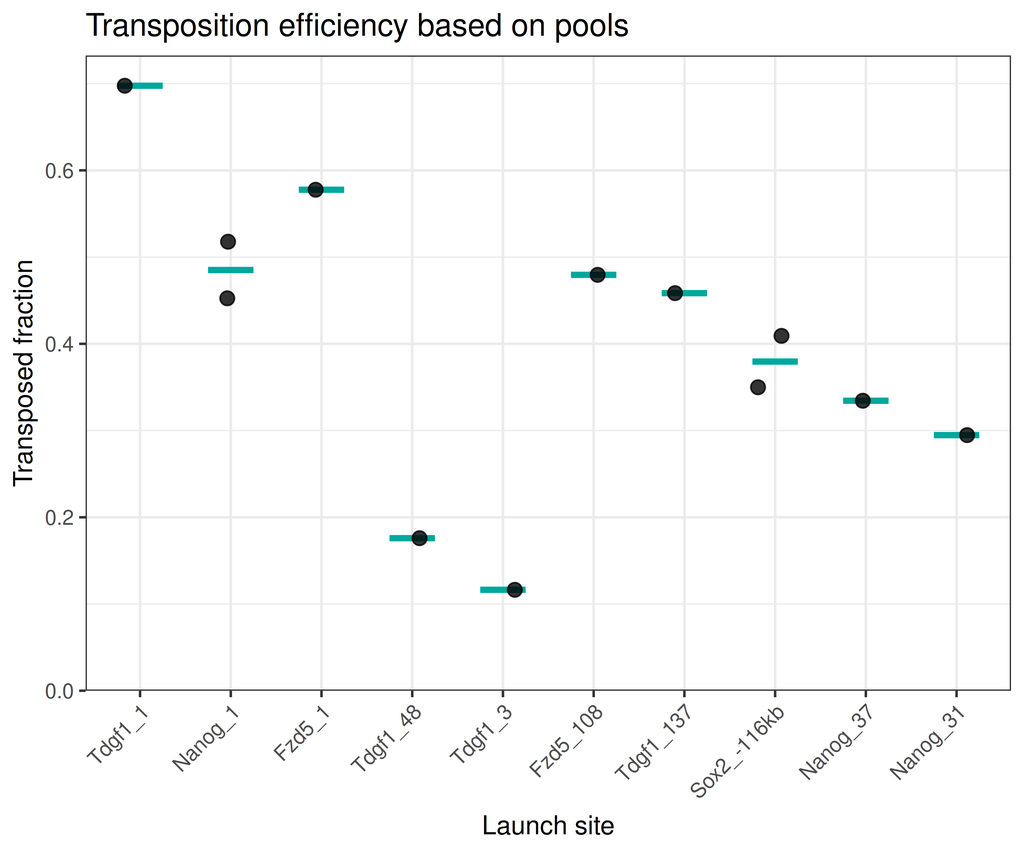

```r
#calculate mean of the bioreps
summary_tib_LD037_CRE =
  hopping_eff_tib_wide_annot2 %>%
  filter(insert %in% c("pLD037", "CRE6")) %>%
  group_by(launch_pad, genotype, bio_rep) %>%
  summarise(mean_hopped_biorep = mean(mean_fract_hopped),
            .groups = "drop") %>%
  group_by(launch_pad, genotype) %>%
  summarise(mean_hopped = mean(mean_hopped_biorep),
            .groups = "drop") %>%
  mutate(launch_pad =  factor(launch_pad,
                             levels = c("Tdgf1", "N1", "Fzd5", "Lise_T48", "Lise_T3", "Lise_F108","Lise_T137",
                                        "C9", "LP23", "LP8", "A1", "C10",
                                         "Lise_N37","Lise_N31", "pJOYC037"),
                             labels = c("Tdgf1_1", "Nanog_1", "Fzd5_1", "Tdgf1_48", "Tdgf1_3","Fzd5_108", "Tdgf1_137",
                                        "xxx", "Sox2_-116kb","xx","xx","xx","Nanog_37", "Nanog_31", "xx")))

#make the plot
hopping_eff_tib_wide_annot2 %>%
  mutate(launch_pad = factor(launch_pad,
                             levels = c("Tdgf1", "N1", "Fzd5", "Lise_T48", "Lise_T3", "Lise_F108","Lise_T137",
                                        "C9", "LP23", "LP8", "A1", "C10",
                                         "Lise_N37","Lise_N31", "pJOYC037"),
                             labels = c("Tdgf1_1", "Nanog_1", "Fzd5_1", "Tdgf1_48", "Tdgf1_3","Fzd5_108", "Tdgf1_137",
                                        "xxx", "Sox2_-116kb","xx","xx","xx","Nanog_37", "Nanog_31", "xx"))) %>%
  filter(genotype == "WT") %>%
  filter(insert %in%  c("CRE6", "pLD037")) %>%
  group_by(launch_pad, bio_rep) %>%
  summarise(mean_fract_hopped_bio_rep = mean(mean_fract_hopped)) %>%

  ggplot(aes(x = launch_pad, y = mean_fract_hopped_bio_rep)) +

  geom_crossbar(
    data = summary_tib_LD037_CRE %>%
      filter(genotype == "WT"),
    aes(
      x = launch_pad,
      y = mean_hopped,
      ymin = mean_hopped,
      ymax = mean_hopped
    ),
    inherit.aes = FALSE,
    width = 0.5,
    color = "#00A79D",
    alpha = 0.5
  ) +
    # raw distribution
  geom_jitter(width = 0.2, height = 0, alpha = 0.8, size = 2.5) +

  #facet_grid(. ~ insert, scales = "free_x", space = "free_x") +
  scale_x_discrete(drop = TRUE) +
  scale_y_continuous(limits = c(0, NA), expand = expansion(mult = c(0,0.05))) +
  ggtitle("Transposition efficiency based on pools") +
  xlab(label = "Launch site") +
  ylab(label = "Transposed fraction") +
  theme_bw() +
  theme(legend.position = "bottom") +
  theme(axis.text.x = element_text(angle = 45, hjust = 1, vjust = 1))
```

# Chromatin context

First process the chromatin data at the launch pad locations. ## process LP chromatin data

```r
#load the encode blacklist regions
blacklist_bed = read_tsv('/DATA/shared/projects/local_hopping/hopping_technology/01_genomewide_chromatin_context/encode_mm10_blacklist.v2.bed', col_names = c("chr", "start", "end", "type"))
#load the background processed tibble
genomic_background_comb = readRDS('/home/c.moene/projects/hopping_technology/01_genomewide_chromatin_background/rds/CM20260330_summary_stats_chrom_background.rds')
```

```r
#location of the pipeline output files
path_context_2000_LPs = '/DATA/shared/projects/local_hopping/hopping_technology/03_hopping_eff_single_LPs/CM20260324_local_context/coverage_results/single_SB_LPs-2000_summary.txt'

#features we want to process
features_oi = c("'H3K9me3_pADam'",  "'LB1_pADam'" , #heterochromatin
                "'EZH2'", "'H3K27me3-2i'", #polycomb
                "'RAD21'" , "'CTCF'", #3D genome
                "'H3K27ac-2i'", "'p300-2i'", #euchromatin
                "'ATAC'", "'DNase'", #accessibility
                "'H3K36me3'", "'POLR2A'", "'TTseq_fw'", "'TTseq_rv'", #transcription
                "'MED1'", "'H3K4me1'", "'H3K4me3'", #CRE
                "'input_1'", "'input_2'" #input samples
                )

#load the tibbles
LP_tib_oi_2000 = read_tsv(path_context_2000_LPs) %>%
  dplyr::select(any_of(c("#'chr'","'start'","'end'" , features_oi)))

#process the chromatin signal at the insertion sites

chrom_LP_2000 = chrom_insert_sites(LP_tib_oi_2000,
                                   filter(genomic_background_comb, window_size == '2000'), #load properly
                                   blacklist_bed,
                                       log_features = c("LB1_pADam", "H3K9me3_pADam"),
                                       non_cistrome_features = c("TTseq_fw", "TTseq_rv"),
                                       input_cols = c("input_1", "input_2")
)



chrom_LP_tib  = chrom_LP_2000 %>%
  dplyr::rename(start_interval = start, end_interval = end)|>
   mutate(start = start_interval + as.numeric(window_size)/2) #actual LP location is 1/2 window size after start window
```

one LP gets filtered out, why?

```r
LP_bins_gr = chrom_LP_2000 %>%
  dplyr::select(chr, start, end) %>%
  distinct() %>%
  GRanges()

findOverlaps(GRanges(blacklist_bed), GRanges(LP_bins_gr))
```

```
## Hits object with 1 hit and 0 metadata columns:
##       queryHits subjectHits
##       <integer>   <integer>
##   [1]      3270           1
##   -------
##   queryLength: 3435 / subjectLength: 16
```

```r
LP_bins_gr[1]
```

```
## GRanges object with 1 range and 0 metadata columns:
##       seqnames              ranges strand
##          <Rle>           <IRanges>  <Rle>
##   [1]     chr9 109076492-109078491      *
##   -------
##   seqinfo: 4 sequences from an unspecified genome; no seqlengths
```

```r
GRanges(blacklist_bed)[3270]
```

```
## GRanges object with 1 range and 1 metadata column:
##       seqnames              ranges strand |               type
##          <Rle>           <IRanges>  <Rle> |        <character>
##   [1]     chr9 109036600-109083500      * | High Signal Region
##   -------
##   seqinfo: 21 sequences from an unspecified genome; no seqlengths
```

So T3 overlaps (the edge of) an encode blacklist region. But the input data does not suggests that there is a mappability problem in our window. Also, in the PB data we did not exclude any LPs purely based on the encode blacklist (the one PB overlapping the blacklist also had an input problem). So I think it is fair to keep this LP in the dataset here.

## link locations to data

First link the pipeline output to the LP names, based on the input file for the chromatin pipeline

```r
LP_locations = read_tsv('/DATA/shared/projects/local_hopping/hopping_technology/03_hopping_eff_single_LPs/CM20260324_LP_locations_clones.txt') %>%
  dplyr::rename(LP_name_old = barcode) %>%
  mutate(launch_pad = case_when(LP_name_old %in% c("161kb", "39kb", "116kb") ~ paste0("-", LP_name_old),
                                LP_name_old == "715kb" ~ "+715kb",
                                LP_name_old == "inSCR" ~ "in SCR",
    .default = LP_name_old
  ))

chrom_LP_tib_annot = left_join(chrom_LP_tib, LP_locations)
```

## plot heatmap

Get overlaps with bed file features (protein-coding genes and LADs)

```r
LP_gene_overlap = read_tsv('/DATA/shared/projects/local_hopping/hopping_technology/03_hopping_eff_single_LPs/CM20260324_local_context/feature_results/overlap_single_SB_LPs_genes.txt',
                          col_names = c('chr_LP', 'start_LP', 'end_LP', 'LP_name', 'chr_gene', 'source', 'feature_type', 'start_gene', 'end_gene', 'X10', 'strand_gene','X12', 'gene_details', 'X14'))

LP_gene_overlap_protcoding = LP_gene_overlap %>%
  filter(grepl('gene_type=protein_coding', gene_details))

LP_gene_overlap_protcoding_forjoin = LP_gene_overlap_protcoding %>%
  dplyr::select(LP_name, chr_gene, start_gene, end_gene)

LP_LAD_overlap = read_tsv('/DATA/shared/projects/local_hopping/hopping_technology/03_hopping_eff_single_LPs/CM20260324_local_context/feature_results/overlap_single_SB_LPs_LADs.txt',
                          col_names = c('chr_LP', 'start_LP', 'end_LP', 'LP_name', 'chr_LAD', 'start_LAD', 'end_LAD','X8'))
LP_LAD_overlap_forjoin = LP_LAD_overlap %>%
  dplyr::select(LP_name, chr_LAD, start_LAD, end_LAD)


LP_context_feature_tib = chrom_LP_tib_annot %>%
  select(launch_pad, chr, start_interval, end_interval) %>%
  dplyr::rename(LP_name = launch_pad) %>%
  distinct() %>%
  left_join(LP_gene_overlap_protcoding_forjoin) %>%
  left_join(LP_LAD_overlap_forjoin) %>%
  mutate(genebody = !is.na(chr_gene),
         LAD = !is.na(chr_LAD))

LP_context_feature_df = LP_context_feature_tib %>%
  dplyr::select(LP_name, genebody, LAD) %>%
  column_to_rownames(var = "LP_name") %>%
  data.frame()
```

```r
#annotate the features
relevant_features = c(
  "H3K9me3_pADam", "LB1_pADam",
  "EZH2", "H3K27me3_2i",
  "CTCF", "RAD21",
  "H3K27ac_2i", "p300_2i",
  "DNase", "ATAC",
  "H3K36me3", "POLR2A", "TTseq_total",
  "MED1", "H3K4me1","H3K4me3")

feature_classes = c(rep('heterochromatin',2),
                    rep('polycomb', 2),
                    rep('genome_folding', 2),
                    rep('euchromatin',2),
                    rep('accessibility', 2),
                    rep('transcription', 3),
                    rep('active_CRE',3))

tib_relevant_features = tibble(feature = relevant_features, feature_class = feature_classes)
df_relevant_features = tib_relevant_features %>%
  column_to_rownames(var = 'feature') %>%
  data.frame()
```

make wide matrix

```r
LP_covs_2000_rel_maps_tibs = chrom_LP_tib_annot %>%
  dplyr::filter(feature %in% relevant_features) %>%
  dplyr::rename(LP_name = launch_pad) %>%
  dplyr::select(chr, start_interval, end_interval, start, LP_name, feature, zscore) %>%
  pivot_wider(names_from = feature, values_from = zscore)

LP_covs_2000_rel_heatmap_matrix = LP_covs_2000_rel_maps_tibs %>%
  dplyr::select(-c(chr, start_interval, end_interval, start)) %>%
  column_to_rownames(var = "LP_name") %>%
  as.matrix()
```

actually make the heatmap

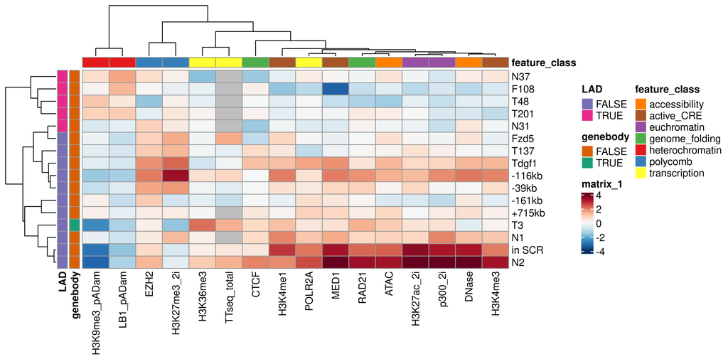

```r
#annotation colors
ann_colors <- list(
  feature_class = setNames(
    brewer.pal(length(unique(df_relevant_features$feature_class)), "Set1"),
    unique(df_relevant_features$feature_class)
  ),
  genebody = setNames(
    brewer.pal(8, "Dark2")[1:2],
    unique(LP_context_feature_df$genebody)
  ),
  LAD = setNames(
     brewer.pal(8, "Dark2")[3:4],
    unique(LP_context_feature_df$LAD)
  )
)

ComplexHeatmap::pheatmap(
  LP_covs_2000_rel_heatmap_matrix,
  scale = "none",                 # IMPORTANT: no additional scaling
  cluster_rows = TRUE,
  cluster_cols = TRUE,
  show_rownames = TRUE,
  show_colnames = TRUE,
  color = colorRampPalette(rev(brewer.pal(n = 11, name="RdBu")))(100),
  breaks = seq(-4, 4, length.out = 101),
  annotation_col = df_relevant_features,
  annotation_row = LP_context_feature_df,
  annotation_colors = ann_colors,
  clustering_distance_rows = 'correlation',
  clustering_distance_cols = 'correlation'
  )
```

## hopping

Here I calculate the mean hopping efficiency by first calculating the mean per biorep (across techreps) and then the mean across bioreps. Filter only for the neutral inserts here, the other inserts are more complex to group correctly (and not needed here).

```r
hopping_eff_tib_wide_annot_for_link = hopping_eff_tib_wide_annot2 %>%
  mutate(launch_pad = case_when(launch_pad == "A1" ~ "in SCR",
                                launch_pad == "C9" ~ "-161kb",
                                launch_pad == "C10" ~ "+715kb",
                                launch_pad == "LP23" ~ "-116kb",
                                launch_pad == "LP8" ~ "-39kb",
                                grepl("Lise_", launch_pad) ~ str_remove(launch_pad, "Lise_"),
                                .default = launch_pad
                                ))

hopping_eff_mean_for_link = hopping_eff_tib_wide_annot_for_link %>%
  filter(insert %in%  c("CRE6", "pLD037")) %>%
  group_by(launch_pad, insert, bio_rep) %>%
  summarize(mean_fract_hopped_biorep = mean(mean_fract_hopped),
            N_techreps = n()) %>%
  group_by(launch_pad, insert) %>%
  summarize(mean_fract_hopped_total = mean(mean_fract_hopped_biorep),
            N_techreps = sum(N_techreps),
            N_bioreps = n())

hop_eff_loc_chrom = left_join(hopping_eff_mean_for_link, LP_locations) %>%
  left_join(chrom_LP_tib, relationship = 'many-to-many') %>%
  filter(!is.na(feature)) #remove LPs that are not in the chromatin data because they were filtered out
```

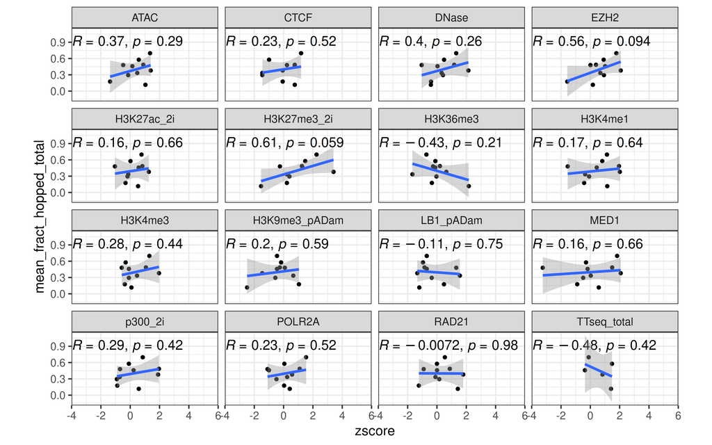

```r
hop_eff_loc_chrom %>%
  filter(insert %in%  c("CRE6", "pLD037")) %>%
  filter(feature %in% relevant_features) %>%
  ggplot(aes(x = zscore, y = mean_fract_hopped_total)) +
  facet_wrap(~feature) +
  geom_point(size = 1) +
  stat_cor(method = 'pearson', label.y = 0.9)+
  scale_x_continuous(limits = c(-4, 6), expand = c(0,0)) +
  geom_smooth(method = 'lm')+
  theme_bw() +
  theme(aspect.ratio = 0.5)
```

The correlations are not really agreeing with what we measured in the PB-SB experiments, but there are only 10 datapoints and the range of covered chromatin is much smaller.

## heatmap relevant LPs only

what are the LPs we have neutral insert hopping data for?

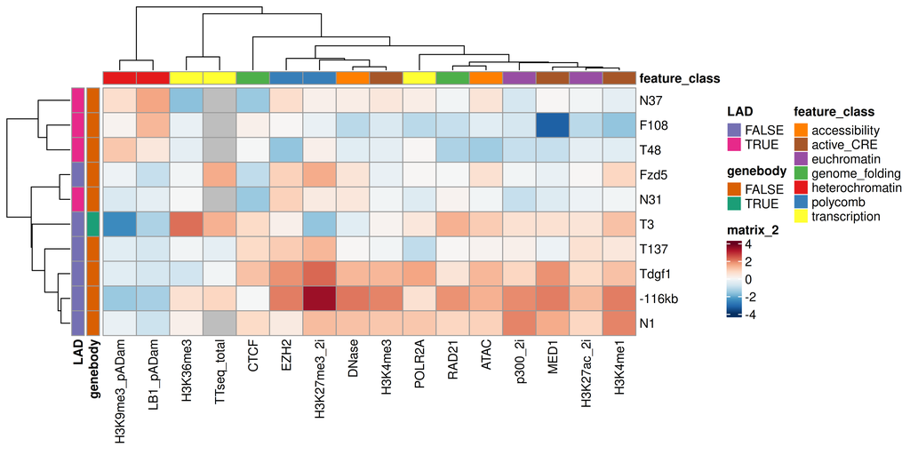

```r
LPs_with_hop_data = hop_eff_loc_chrom %>%
  filter(insert %in%  c("CRE6", "pLD037")) %>%
  pull(launch_pad) %>% unique()

ph = ComplexHeatmap::pheatmap(
  LP_covs_2000_rel_heatmap_matrix[LPs_with_hop_data,],
  scale = "none",                 # IMPORTANT: no additional scaling
  cluster_rows = TRUE,
  cluster_cols = TRUE,
  show_rownames = TRUE,
  show_colnames = TRUE,
  color = colorRampPalette(rev(brewer.pal(n = 11, name="RdBu")))(100),
  breaks = seq(-4, 4, length.out = 101),
  annotation_col = df_relevant_features,
  annotation_row = LP_context_feature_df[LPs_with_hop_data,],
  annotation_colors = ann_colors,
  clustering_distance_rows = 'correlation',
  clustering_distance_cols = 'correlation'
  )

ph =  ComplexHeatmap::draw(ph)
```

```r
order_of_clones = rownames(LP_covs_2000_rel_heatmap_matrix[LPs_with_hop_data,])[ComplexHeatmap::row_order(ph)]
```

barplot

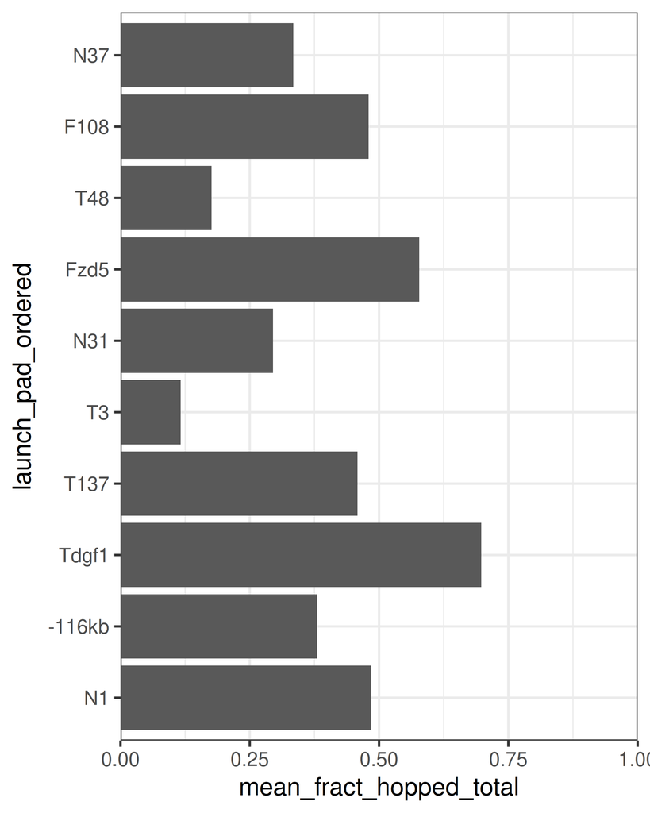

```r
hopping_eff_mean_for_link %>%
  filter(launch_pad %in% order_of_clones) %>%
  mutate(launch_pad_ordered = factor(launch_pad, levels = rev(order_of_clones))) %>%
  ggplot(aes(y = launch_pad_ordered, x = mean_fract_hopped_total )) +
  geom_col() +
  scale_y_discrete()+
  scale_x_continuous(limits = c(0,1), expand = c(0,0)) +
  theme_bw()
```

# Extract numbers

I need a few numbers for the text. What is the overall hopping efficiency in the PB-SB hopping?

```r
hopping_eff_tib_wide_annot2 %>%
  filter(insert == "pJOYC037") %>%
  filter(bio_rep %in% c('rep2','rep3')) %>% #we decided not to use the older, less complex replicate
  dplyr::select(sample_group, mean_fract_hopped) %>%
  kable()
```

| launch_pad | sample_group | mean_fract_hopped |
| --- | --- | --- |
| pJOYC037 | E2902_WT78_1_SB | 0.4398380 |
| pJOYC037 | E2902_WT78_2_SB | 0.4381574 |
| pJOYC037 | E2902_WT79_1_SB | 0.4718907 |
| pJOYC037 | E2902_WT79_2_SB | 0.4920686 |
| pJOYC037 | E2902_WT83_1_SB | 0.4353586 |
| pJOYC037 | E2902_WT83_2_SB | 0.4290591 |

```r
hopping_eff_tib_wide_annot2 %>%
  ungroup()%>%
  filter(insert == "pJOYC037") %>%
  filter(bio_rep %in% c('rep2','rep3')) %>% #we decided not to use the older, less complex replicate
  dplyr::select(sample_group, mean_fract_hopped) %>%
  pull(mean_fract_hopped) %>% summary()
```

```
##    Min. 1st Qu.  Median    Mean 3rd Qu.    Max.
##  0.4291  0.4361  0.4390  0.4511  0.4639  0.4921
```

```r
#mean per parental clone
hopping_eff_tib_wide_annot2 %>%
  ungroup()%>%
  filter(insert == "pJOYC037") %>%
  filter(bio_rep %in% c('rep2','rep3')) %>% #we decided not to use the older, less complex replicate
  mutate(parental_clone = str_extract(sample_group, "WT..")) %>%
  dplyr::select(sample_group,parental_clone, mean_fract_hopped) %>%
  group_by(parental_clone) %>%
  summarise(mean_fract_hopped = mean(mean_fract_hopped)) %>%
  mutate(home_reads = 1-mean_fract_hopped)
```

```
## # A tibble: 3 × 3
##   parental_clone mean_fract_hopped home_reads
##   <chr>                      <dbl>      <dbl>
## 1 WT78                       0.439      0.561
## 2 WT79                       0.482      0.518
## 3 WT83                       0.432      0.568
```